# Developing Bioconductor-friendly packages using biocthis

David Zhang

UCL

21 November 2020

> Aim: Give overview of principles behind and hands-on practice for developing Bioconductor-friendly packages using biocthis.

# 1 Outline

1. Why make R/Bioconductor packages?
2. What do R packages consist of?
3. Testing fundamentals.
4. How to make Bioconductor-friendly packages using `biocthis`?
5. Practical run through - making your own `utils` package.

# 2 Why make R/Bioconductor packages?

## 2.1 R packages

- **Share** functions with others/yourself (with `git`).
- Improving the **organization** of your functions - e.g. mentality, documentation, continuous updates.
- Integrated **unit testing** to keep your functions robust to future changes.

Useful resources:

1. R packages [book](https://rstudio.com/products/rpackages/)
2. [Your first R package in 1 hour](https://www.pipinghotdata.com/posts/2020-10-25-your-first-r-package-in-1-hour/)

## 2.2 Bioconductor packages

- **Share** code more widely with Bioconductor community.
- Code review, learning about developing software - forced compliance with Bioconductor standards.
- More citations - https://www.biorxiv.org/content/10.1101/2020.11.16.385211v1
- CV/reputation points.

# 3 What do R packages consist of?

## 3.1 States of R packages

- The structure of R packages is explained well [here](https://r-pkgs.org/package-structure-state.html).
- 5 states: source, bundles, binary, installed, in-memory (Table 3.1)

Table 3.1: Different states of R packages

| state | description |
| --- | --- |
| source | A set files/directories in a set structure. The state you develop with and encounter with when cloning a repo. |
| bundles | Source compressed into a single tar.gz (e.g. through devtools::build()) |
| binary | Binary version (e.g. distributed by CRAN). Can be generated through devtools::build(binary = TRUE) |
| installed | Either the binary or bundle that's decompressed and placed into your R package library (using install.packages()) |
| in-memory | Load a package into memory using library() or devtools::load_all() |

## 3.2 Structure of R packages

R packages have several key components, which are shown below in figure 3.1 taken from [here](https://github.com/lcolladotor/biocthis) and detailed in table 3.2.

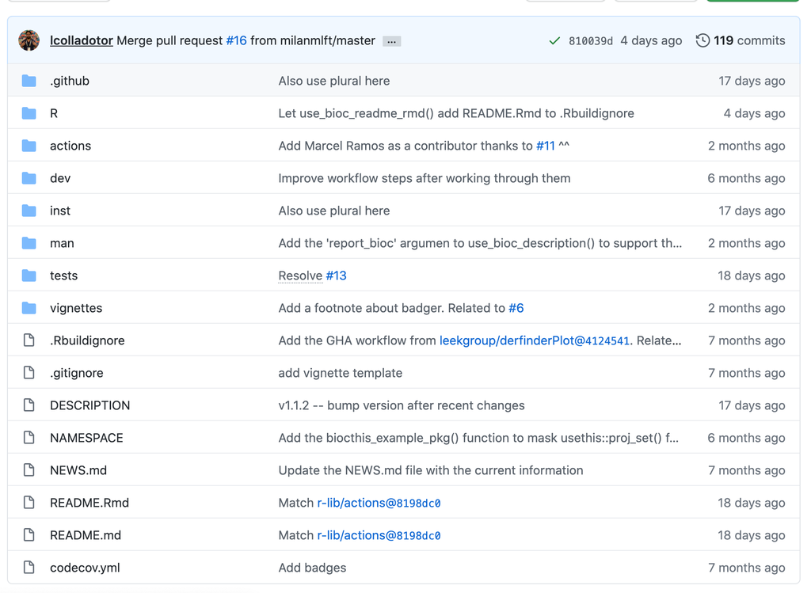

Figure 3.1: biocthis package structure

Table 3.2: Key components of R packages

| state | description |
| --- | --- |
| .github | The GitHub actions workflow. |
| R | Contains all the code for the functions of your package. |
| inst | Additional raw data in the package you would like available to the user. |
| man | Function documentation generated by Roxygen |
| tests | Unit tests for functions |
| vignettes | vignette description usage of your package |
| DESCRIPTION | Author details, licence, dependencies and general summary of your package |
| README | Read me documentation shown at the GitHub repository |

# 4 Testing fundamentals

3 levels of testing:

1. **Unit testing** individual functions
2. **R CMD Check or BiocCheck** checks that you’re package can be built, installed and complies to R/Bioconductor package guidelines.
3. Testing across multiple **operating systems** using GHA

## 4.1 Unit testing

- For complicated code, ensures future updates do not break existing functionality.
- You do this already, just manually.
- `testhat` automates this for R packages.
- Rule of thumb: If you catch a bug, write a test.
- Metrics, try to be fast + comprehensive.

## 4.2 R CMD Check or BiocCheck

- Reports ERROR/WARNINGS/NOTES.
- R CMD Check that your package meets certain criteria:
  - Runs all unit tests
  - Have you documented your functions?
  - Have you written a proper DESCRIPTION?
  - Have you used “:::”?
- BiocCheck is more “stringent”:
  - Are your functions less than 80 lines?
  - Do >80% have examples?

## 4.3 Testing across Linux/Mac/Windows

- A great lecture on GHA basics from Jim Hester can be found [here](https://www.jimhester.com/talk/2020-rsc-github-actions/)
- GitHub actions is used in this case for testing, but is very flexible
- On an event, do something
- Written in yet-another-markdown-language (YAML)
- GitHub has “runners” based on Linux/Mac/Windows OS (and permits dockers)
- We run R CMD Check and BioCheck on all 3 to catch OS-specific issues

# 5 How to make Bioconductor-friendly packages using `biocthis`?

## 5.1 usethis

- [usethis](https://usethis.r-lib.org/) has a lot of functions to enable easy package development.
- `usethis::create_package()` - creates package skeleton
- `usethis::use_r()` - creates .R function skeleton
- `usethis::use_git()` - connects current package to git.
- `usethis::use_github()` - create a GitHub repo for current repo.
- `usethis::use_github_action()` - creates GHA skeleton

## 5.2 biocthis

- Builds upon `usethis` specifically for Bioconductor packages.
- Still under active development.